# Introduction

In Zebradb the concept of variable domain is the set of all possible values a variable can have, for example, given the following zebradb definitions:

- (number 0)
- (number 1)
- …
- (number 9)
- and the query ?(number ʹ*v*)

The query will unify with all (number 0) …(number 9) definitions and therefor ʹ*v* ∈ [0…9] which is the ʹ*v* domain.

# Why Zebradb needs them (The Problem)

When zebradb search for query solutions, it unifies query tuples with definitions, for each unification it creates a branch that will contain unification changes.

Using the previews example, the query ?(number ʹ*v*) will create 10 branches:

- (number 0) unify (number ʹ*v*) = (number 0)
- (number 1) unify (number ʹ*v*) = (number 1)
- …
- (number 9) unify (number ʹ*v*) = (number 1)

This is a simple query, the problem is when we start to have queries with more variables, even a simple definition like ((number ’x) (number ’y)) will create 100 branches to solve the query ?((number ’x) (number ’y)).

The exponential growth of branches its a critical problem that needs to be solved to make zebradb useful.

To solve this problem we are still using branches for each unification, because this enables unification to run in parallel, but after each tuple unification we extract variable domains, reducing the number of branches.

For example, the query ?((number ’x) (number ’y)) can be solved has ʹ*x* ∈ [0…9] and ʹ*y* ∈ [0…9] dramatically reducing the number of branches needed for next iteration.

# The Solution

As state on this post the solution I am investigating is the construction of variable domains, however this is not as simple has extracting values, because we need to consider two complications:

1. Deferred variables, a variable domain should not contain other variables,
2. Variable dependencies, variable domains are affected by other variables values.

For example, the NAND operator can be defined as:

1. (0 nand 0 = 1)
2. (0 nand 1 = 1)
3. (1 nand 0 = 1)
4. (1 nand 1 = 0)

Now consider the query ?(’p nand ’q = ’r)

1. If p=0 and ’r=1 then ʹ*q* ∈ [0, 1]
2. If ’q=0 and ’r=1 then ʹ*p* ∈ [0, 1]
3. Else ’p=1 and ’q=1 and ’r=0

This gives us 3 branches, sometimes we don’t win much or nothing using domains, in this case 3 is better then 4, so its a small win.

So I am working on an algorithm to extract domains, using automaton minimization, I will explain it with other example.

Consider the following definitions:

1. (mary likes food ’)
2. (mary likes wine ’)
3. (john likes wine ’)
4. (john likes mary ’)
5. (peter likes peter ’)
6. (john likes ’stuff (mary likes ’stuff ’)) # 1. John likes anything that Mary likes
7. (john likes ’person (’person likes wine ’)) # 2. John likes anyone who likes wine

And the query: ?(john likes ’stuff ’p)

First we extract query variables [’stuff, ’p], and then we construct a finite automaton using values extracted from branches generated by unifying the query with the definitions,

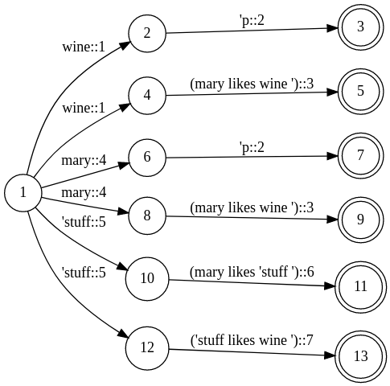

The first level of values on the automaton corresponds to the first variable ’stuff and the second level to variable ’p. Basically we are creating an automaton with words that encode variable and value, similar has having tuple (variable, value) as automaton words.

And next I perform a minimization:

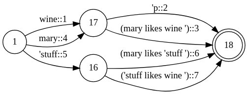

And now I extract domains from minimized automaton, there is 2 rules for extraction:

1. There is a domain for each to state,
2. Domains can’t contain variables and values at same time, so if we find a variable we split domain.

So in this example to extract domain do the following steps:

1. We start from state 1 (start state),
2. Extract domain from state 1 to 17, stuff = [wine, mary],
3. Extract domain from state 17 to 18, p = [’p, (mary likes wine ’)],
4. So the resulting domain is {stuff: [wine, mary], p: [’p, (mary likes wine ’)]},
5. Since p contains a variable we need to split domain: [ {stuff: [wine, mary], p: [’p]}, {stuff: [wine, mary], p: [(mary likes wine ’)]} ],
6. From start to state 16, extract domain: stuff = [’stuff],
7. From 16 to 18 extract domain: p = [(mary likes ’stuff), (’stuff likes wine)],
8. resulting domain is: {stuff: [’stuff], p: [(mary likes ’stuff), (’stuff likes wine)]}

And finally we get the list of possible domains: [ {stuff: [wine, mary], p: [’p]}, {stuff: [wine, mary], p: [(mary likes wine ’)]}, {stuff: [’stuff], p: [(mary likes ’stuff), (’stuff likes wine)]} ]

After having the domains, we create branches changing variables to domains or to values/variables (case domain is length 1)

The final result is like this:

1. ?(john likes ’stuff ’p):
   1. @(john likes ’stuff v$83 : (’stuff likes wine ’$1) (mary likes ’stuff ’));
   2. @(john likes v$80 : mary wine ’p);
   3. @(john likes v$80 : mary wine @(mary likes wine ’))

And thats it, if we try to expand domains we get:

1. ?(john likes ’stuff ’p):
   1. @(john likes ’stuff (’stuff likes wine ’$1));
   2. @(john likes ’stuff (mary likes ’stuff ’));
   3. @(john likes mary ’p);
   4. @(john likes wine ’p);
   5. @(john likes mary @(mary likes wine ’))
   6. @(john likes wine @(mary likes wine ’))

So we actually got a pretty good compression, representing 6 branches with only 3 branches.

The next step is to handle tuples on the rest of processing pipeline, thats why the first two items of expanded tuples are an incomplete solution.

Thats it.